# How uncertain is the Index of Multiple Deprivation?

Working note: what open data can tell us about error in the IMD 2025, what shrinkage reveals, and how wide the rank ranges are

Author

Drafted by Claude Code (Claude Opus 5.5) for Dan Olner

Published

10 November 2026

This note follows on from the [research note on IMD uncertainty](https://github.com/DanOlner/RegEconWorks/blob/master/llm_output/imd_rank_uncertainty_research.md), which lists all 55 indicators behind the [English Indices of Deprivation 2025](https://www.gov.uk/government/statistics/english-indices-of-deprivation-2025) and how they are weighted and combined. It asks how far the published IMD ranks of LSOAs and local authorities can be told apart once error in the underlying data is allowed for. It:

1. Rebuilds as much of the IMD as the published files allow, including the step from indicators to domains (section 1).
2. Sets out what open data can and can’t tell us about the IMD’s error, given that most of the data behind it is held in secure settings (section 2).
3. Explores whether the IMD’s own shrinkage step can be run backwards to recover each LSOA’s error, and tests that on real and made-up data (section 3).
4. Carries the error in the Income and Employment domains through to every LSOA’s and local authority’s rank, under two error models, and checks whether the resulting ranges cover the truth (section 4).
5. Adds error in the other five domains, in layers from what open data can size to what has to be assumed (section 5).
6. Puts formal confidence sets on local authority ranks (section 6).

This is the second version. The first was reviewed in llm_output/imd_uncertainty_review_and_plan.md, and this version works through that plan as far as it can go without logins for the GeoDS area classification and DWP Stat-Xplore. Everything here is my own calculation from published, open files unless it says otherwise. The R scripts are in code/imd_uncertainty, and `00_run_all.R` there rebuilds everything from scratch.

## Summary

- **Stages 4 to 7 of the IMD can be rerun from published files.** Stages 5 to 7 reproduce the published IMD ranks (all but one swapped pair) and all five local authority summary measures and their ranks. Stage 4, from indicators to domains, rebuilds every domain to within the rounding of the published indicators, and settles two method details the technical report leaves out (section 1).
- **Chance error can be estimated directly for under half the IMD’s weight.** 46.9% of the weight has published counts, or counts that can be rebuilt from open sources. Another 17.0% is shrunk rates whose counts can be recovered with a denominator. The rest is ratios and scores with no count (17.8%), modelled values with no error (12.4%) or secure pupil data (5.8%).
- **Running shrinkage backwards works on real data.** Inverting the published Income, Employment, IDACI and IDAOPI rates gives back the published counts to within their rounding for 84% to 90% of LSOAs, and an error within a few percent of the one the real counts imply. Getting the denominator or parent groups wrong can push the error either way, not only up, as the first version said.
- **The road casualty indicator doesn’t look shrunk.** Rebuilt from DfT’s open records, the unshrunk rate matches the published one (rank correlation 0.982), and 1,274 of the 1,278 LSOAs published at exactly zero had no casualties at all. Shrinkage as described would have lifted them off zero.
- **LSOA rank ranges are wide, and the first version’s lower bound was too low.** Carrying only Income and Employment chance error to the IMD, the median 90% range is 1,306 ranks under the Indices’ own error model and 2,237 once the two domains’ errors are allowed to move together and to vary more than a binomial count. Between 312 and 548 of the 3,375 LSOAs published as the most deprived 10% are less than 95% likely to belong there.
- **The ranges cover the truth when the error model is right, and not when it’s too optimistic.** In a test with a known answer, 90% ranges contain the true rank 90% of the time when the error model is right, but only 66% when the real error is the correlated, more variable kind and the analysis assumes the Indices’ own model.
- **Adding the other domains widens the ranges further.** Adding the chance error that open data can size (crime, overcrowding, adult skills, road casualties) takes the median LSOA range to 1,609 ranks. Adding assumed errors for everything else takes it to 2,885. That last figure rests on guesses, set out in section 5.
- **Local authorities are much better separated, until shared errors come in.** On average score, their 90% ranges are 2.5 to 4 ranks wide from Income and Employment error, and 16 with assumed errors shared across each authority’s LSOAs. Formal simultaneous confidence sets are wider still (section 6).

## 1. How the IMD is built, and the parts that can be rerun

The IoD 2025 builds the IMD in seven stages (technical report section 3.1). The first three (choosing domains and indicators, building indicators from microdata, and shrinkage) happen inside the research team’s and data suppliers’ systems. The last four can now be rerun from published files:

- **Stage 4.** Indicators are combined into domain scores, via sub-domains where a domain has them.
- **Stage 5.** Each domain score is ranked across all 33,755 LSOAs, and the rank is transformed to an exponential distribution from 0 to 100 that stretches out the most deprived 10%.
- **Stage 6.** The transformed scores are added with fixed weights, and the total is ranked.
- **Stage 7.** LSOA scores and ranks are summarised, weighted by population, for each of the 296 local authorities.

| Domain | Weight | How its indicators are combined |
| --- | --- | --- |
| Income | 22.5% | Non-overlapping benefit counts ÷ total population (9 indicators) |
| Employment | 22.5% | Non-overlapping benefit counts ÷ population aged 18 to 66 (12 indicators) |
| Education, skills and training | 13.5% | Children and young people (5 indicators, factor-analysis weights) and adult skills (1), combined 50/50 |
| Health and disability | 13.5% | 4 indicators, one a 4-part mental health composite, factor-analysis weights |
| Crime | 9.3% | 8 police-recorded rates, factor-analysis weights |
| Barriers to housing and services | 9.3% | Geographical barriers (1) and wider barriers (5 items), combined 50/50 |
| Living environment | 9.3% | Indoors (3) and outdoors (3), equal weights within each, combined 70/30 |

### Stages 5 to 7

Table 1: Rerunning stages 5 to 7 from the published files. Sources: IoD 2025 Files 7, 9 and 10; my calculation.

| Check | Result |
| --- | --- |
| Exponential transform of each published domain rank, against File 9 | Largest difference 0.0024 (File 9 is rounded to 3 decimal places) |
| IMD score as the weighted sum of File 9 scores, against File 7 | Largest difference 0.0008; correlation 1.000000 |
| IMD rank from the exact (unrounded) transform of the published domain ranks, against File 7 | All but 2 LSOAs (one pair swapped) match exactly |
| All five local authority summary measures (average score, average rank, proportion in the most deprived 10%, extent, local concentration), against File 10 | 5 of 5 measures match for all 296 authorities, to File 10’s rounding, and every rank is identical |

So any change to the domain ranks can be carried through to IMD and local authority ranks exactly as MHCLG would. The first version checked three of the five local authority measures; extent and local concentration (technical report Appendix M) now match too.

### Stage 4: from indicators to domains

File 8 publishes the indicators for four of the seven domains, and File 7 publishes every sub-domain score. Rebuilding each domain with the method in chapter 4 of the technical report:

Table 2: Rebuilding domain and sub-domain scores from the published indicators. Rank differences are in places, out of 33,755. Sources: IoD 2025 Files 7 and 8; my calculation.

| Domain or sub-domain | Correlation | Largest score difference | Median rank difference | 99th percentile rank difference |
| --- | --- | --- | --- | --- |
| Crime domain (8 indicators, factor weights) | 0.99999 | 0.059 | 20 | 122 |
| Health domain (4 indicators, factor weights) | 1.00000 | 0.003 | 2 | 12 |
| Housing affordability item (2 components) | 1.00000 | 0.084 | 11 | 58 |
| Wider barriers sub-domain (5 items) | 0.99998 | 0.286 | 16 | 245 |
| Indoors living environment sub-domain (3) | 1.00000 | 0.024 | 15 | 71 |
| Outdoors living environment sub-domain (3) | 0.99949 | 0.488 | 20 | 764 |
| Geographical barriers sub-domain (1) | 1.00000 | 0.000 | 0 | 2 |
| Adult skills sub-domain (1) | 1.00000 | 0.000 | 26 | 123 |
| Education domain (from published sub-domain ranks) | 1.00000 | 0.001 | 0 | 0 |
| Barriers domain (from published sub-domain ranks) | 1.00000 | 0.000 | 0 | 0 |
| Living environment domain (from published sub-domain ranks) | 1.00000 | 0.000 | 0 | 0 |

What the rebuild shows:

- **The normal-score formula.** The report says indicators are “ranked and transformed to a normal distribution” but doesn’t give the formula. The inverse normal of rank ÷ (N + 1), with tied values sharing their average rank, rebuilds the Health domain to within 0.0034, about what the 3-decimal-place inputs allow. Two other common choices miss by up to 0.08.
- **How wider barriers is combined.** The sub-domain is the *sum* of its five normal scores, and each composite item (housing affordability, overcrowding, homelessness) is turned back into a normal score before it is added. Regressing the published score on the five re-standardised items gives coefficients of 0.999 to 1.001 and no intercept. The report says only “equal weights”, so this answers one of the open questions in the research note (section 3.7).
- **Rounding limits the rest.** The crime rates are published to one decimal place, so 99.4% or more of LSOAs share their value with another LSOA. That is why the rebuilt Crime ranks differ by a median of 20 places. The Outdoors misses are almost all in the 1,278 LSOAs with a published road casualty rate of exactly 0 (section 3.6).
- **The two-sub-domain domains rebuild exactly** from the published sub-domain ranks.

So indicator-level error can be carried through to the IMD. Section 5 does that by adding the change each perturbation makes to the rebuilt score onto the published score, so that rounding in File 8 doesn’t move the starting point.

## 2. What open data can and can’t tell us

Figure 1 shows how much of each domain’s weight sits on each kind of data. Table 3 gives the totals and what each kind allows.

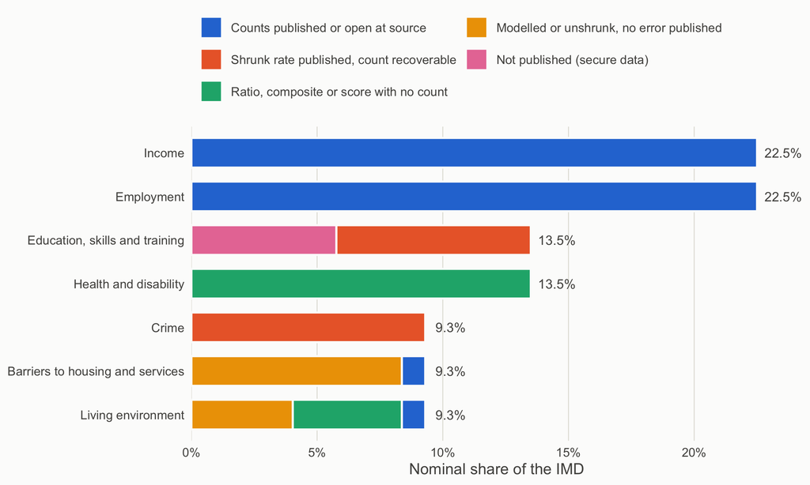

Figure 1: Nominal share of the IMD by domain and by what the open data allow for each indicator. Nominal shares multiply the domain, sub-domain and indicator weights; ranking and the exponential transforms change each indicator’s real influence. Sources: IoD 2025 technical report and File 8; DfT and Census 2021 for the indicators rebuilt from open sources; my calculation.

Table 3: What the open data allow for each indicator. Share is the nominal share of the IMD. Sources: IoD 2025 technical report and File 8 notes; my calculation.

| What the open data allow | Indicators | Share | Examples | What it allows |
| --- | --- | --- | --- | --- |
| Counts published or open at source | 5 | 46.9% | Income and Employment domains; overcrowding (Census 2021 tables); road casualties (DfT open data) | Chance error estimated directly from counts and denominators. Limits: Income and Employment counts rounded to the nearest 5 and suppressed under 10; no LSOA error for the population denominators. |
| Shrunk rate published, count recoverable | 10 | 17.0% | Crime (8), adult skills, entry to higher education | Counts recovered by running shrinkage backwards, given a denominator and parent groups (section 3). The crime at-risk denominators and the 2025 parent groups are not published, so the result is approx… |
| Ratio, composite or score with no count | 9 | 17.8% | Illness and disability ratio, years of life lost, acute morbidity, mental health composite, energy performance and outdoor space scores | Needs expected counts from national age-sex rates and LSOA age structure (not attempted), or the property-level data. The mental health components are published only as a composite of normal scores. |
| Modelled or unshrunk, no error published | 10 | 12.4% | Connectivity, housing affordability, homelessness (local authority level), broadband, GP ratio, air quality, poor housing, noise | No error model at all. Model error would have to come from the modellers (DfT, Heriot-Watt, BRE, Defra, Ofcom), or be assumed and varied (section 5). |
| Not published (secure data) | 4 | 5.8% | Key Stage 2 and 4, pupil absence, persistent absence | Nothing at LSOA level (DfE restriction). Only the children and young people sub-domain score is published. Needs secure access to the National Pupil Database, or an assumed error. |

What this means for understanding the IMD’s uncertainty:

- **Nobody outside the research team can check stages 1 to 3.** The microdata are held in secure settings: DWP’s benefit systems, Home Office asylum records, the National Pupil Database, hospital and mental health records, ONS deaths, and raw police records that could only be processed inside Lancashire Constabulary. The technical report says even the external assessor checked the sensitive parts only after they had been aggregated to LSOAs (paragraph 5.3.18).
- **Some inputs are open at source, and that changes what can be tested.** Road casualties come from DfT’s open STATS19 data and overcrowding from Census 2021 tables. Rebuilding them from source showed that the road casualty indicator doesn’t behave as if it had been shrunk (section 3.6), which nothing in the published files alone could have shown.
- **Systematic error is invisible in every published file.** Benefit take-up that varies between areas, differences in police recording practice between the 39 forces, uneven NHS trust submissions, and mismatched time points (2024 numerators over mid-2022 denominators) all move LSOAs in ways no published number reveals. Section 5 includes some as assumed, shared errors; sizing them properly needs outside benchmarks.
- **Even the shrinkage groups are gated.** The 2025 shrinkage pulls each LSOA towards LSOAs of the same area-classification supergroup in its local authority. That classification ([GeoDS 2021/2 LSOAC](https://data.geods.ac.uk/dataset/lsoac)) is open-licensed but can only be downloaded after registering, so this note uses the local authority as the parent, as the 2019 Indices did.
- **The cheapest fix sits with MHCLG and the research team (my suggestion).** They already compute, for every shrunk indicator, each LSOA’s raw variance and shrinkage weight. Publishing the posterior standard error of each published rate, rounded as the rates are, would let anyone carry chance error through the whole index. It wouldn’t suit the DfE pupil data, but there a standard error for the published sub-domain score would do. Publishing the parent-group lookup and the at-risk denominators would also help.

## 3. Reading error from the shrinkage step

### 3.1 The idea

For an LSOA with $r$ events out of $n$, the shrinkage step (technical report Appendix C) works on the empirical logit $m = \log\frac{r + 0.5}{n - r + 0.5}$, whose variance is $s^2 = \frac{(n+1)(n+2)}{n(r+1)(n-r+1)}$. It pulls $m$ towards the parent group’s pooled logit $M$:

$$m^* = w\,m + (1 - w)\,M, \qquad w = \frac{1/s^2}{1/s^2 + 1/t^2},$$

where $t^2$ is the spread of the raw logits within the group. In the usual empirical Bayes reading, $m^*$ is the posterior mean of the LSOA’s underlying rate and its **posterior variance is $w\,s^2$** (my reading; the report gives only the point estimate). Two things follow:

- If $r$ and $n$ are known, the error of every published shrunk rate can be computed.
- The pull, $m^* - m = (1 - w)(M - m)$, encodes $w$, and through it $s^2$. So given the denominator and the parent group, a published rate can be solved back to its count, and so to its error.

### 3.2 Income and Employment, where the counts are published

Table 4: Rebuilding the shrinkage step from published counts, with the local authority as the parent group. ‘Pull’ is how far shrinkage moved each LSOA on the logit scale. The rounding-only benchmark adds back the rounding of the counts (to the nearest 5) and of the rates (to 3 decimal places). Sources: IoD 2025 Files 6, 7 and 8; my calculation.

| Domain | LSOAs | Median count | Correlation, published vs rebuilt rate | Correlation, published vs rebuilt pull | Same, if rounding were the only difference | Median weight on own data (w) | Median relative SE of rate |
| --- | --- | --- | --- | --- | --- | --- | --- |
| Income | 33,750 | 310 | 0.99997 | 0.77 | 0.91 | 0.994 | 5.1% |
| Employment | 33,734 | 115 | 0.99965 | 0.82 | 0.89 | 0.976 | 8.6% |

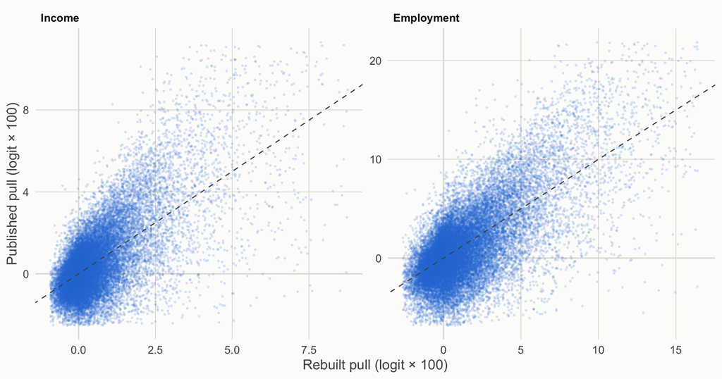

Figure 2: How far shrinkage moved each LSOA: rebuilt with the local authority as parent (x) against what the published rates imply (y), logit scale × 100 (roughly the percentage change in the odds). The dashed line is equality. The most extreme 0.5% of LSOAs at each end are off the axes. Sources: IoD 2025 Files 6 to 8; my calculation.

- **Shrinkage hardly touches these two domains.** The weight on each LSOA’s own data has a median of 0.994 (Income) and 0.976 (Employment), so the posterior errors are almost the plain binomial errors: about 5% and 9% of the rate.
- **The rebuild explains only part of the pull.** The rebuilt pull correlates 0.77 and 0.82 with the published one, against 0.91 and 0.89 if rounding were the only difference. Section 3.3 tests whether the rest is the 2025 supergroup parents.

### 3.3 Testing the reading on the IoD 2019

In 2019 every LSOA was shrunk towards its local authority, so the parent group is known. If the same rebuild on 2019 data reaches its rounding-only benchmark, the method is being read correctly.

Table 5: The shrinkage rebuild with local authority parents, on the IoD 2019 (where that was the parent) and the IoD 2025 (where it wasn’t). Sources: IoD 2019 and 2025 Files 6 to 8; my calculation.

| Domain | Edition | Median count | Correlation of pulls | Same, if rounding were the only difference | Median w |
| --- | --- | --- | --- | --- | --- |
| Income | IoD 2019 | 165 | 0.85 | 0.81 | 0.988 |
| Income | IoD 2025 | 310 | 0.77 | 0.91 | 0.994 |
| Employment | IoD 2019 | 75 | 0.34 | 0.83 | 0.964 |
| Employment | IoD 2025 | 115 | 0.82 | 0.89 | 0.976 |

- **Income: the reading holds.** The 2019 rebuild reaches its benchmark (0.85 against 0.81). So for Income the 2025 gap is very likely the change to supergroup parents, which pull each LSOA towards similar areas and so move it less: the published 2025 pull is about 71% of the rebuilt one.
- **Employment: it doesn’t, in 2019.** The 2019 Employment rebuild explains little of the pull (0.34 against 0.83). Something about how the 2019 Employment domain was shrunk differs from the reading here: perhaps the separate benefits were shrunk before being added, or the denominator differed. So the supergroup explanation is supported by Income, not by Employment.

The 2025 Employment numerator is the average of 12 monthly counts, and the 2019 one, as I recall the 2019 technical report (not rechecked here), the average of four quarterly counts. That raises the same question as for crime (section 3.5): was shrinkage applied to the average count or to the counts pooled over the time points? If pooled, the variance would be 4 or 12 times smaller and the pull much weaker. Here the counts are known, so it can be tested:

Table 6: Were the counts pooled over time points before shrinkage? Rebuilds with the average count (multiplier 1) and with the counts pooled over the quarters (2019) or months (2025). ‘Slope’ regresses the published pull on the rebuilt pull: 1 means the pull is the right size. Sources: IoD 2019 and 2025 Files 6 to 8; my calculation.

| Edition | Counts multiplied by | Correlation of pulls | Slope | Median w |
| --- | --- | --- | --- | --- |
| IoD 2019 | 1 | 0.34 | 0.27 | 0.964 |
| IoD 2019 | 4 | 0.35 | 0.97 | 0.991 |
| IoD 2025 | 1 | 0.82 | 0.97 | 0.976 |
| IoD 2025 | 12 | 0.59 | 0.98 | 0.998 |

The evidence is mixed. In 2019 the pull is the right size only if the quarters were pooled (slope 0.97 against 0.27). In 2025 the slope can’t tell the two apart, but the shape of the pull fits the average count much better (correlation 0.82 against 0.59). For 2025 that leans towards the “annual average” reading, which section 3.5 uses as the main case for crime.

### 3.4 Can the error be recovered from shrunk rates alone?

**A made-up test.** Take the real LSOA populations and local authorities, make up true rates proportional to the Income rates, scaled so the average LSOA expects 3 to 300 events, draw counts, shrink them the IoD way and publish the shrunk rates. Then solve the shrinkage equations backwards (`invert_shrinkage()`), using only the published rates, an assumed denominator and assumed parent groups.

Table 7: Synthetic test of running shrinkage backwards, at three sizes of count. ‘SE ratio’ is the recovered posterior standard error over the true one (1 = exact; above 1 = overstated). Coverage is the share of LSOAs whose true rate lies inside a 90% interval. Sources: IoD 2025 Files 7 and 8 for populations and rate pattern; simulated data; my calculation.

| Expected count | Case | Median w, true | Median w, recovered | Median SE ratio (10th to 90th percentile) | Coverage, recovered |
| --- | --- | --- | --- | --- | --- |
| 3 | Everything known | 0.68 | 0.68 | 1.00 (1.00 to 1.00) | 85% |
| 3 | Rounded like crime | 0.68 | 0.68 | 1.00 (0.94 to 1.06) | 84% |
| 3 | Rounded, denominator 25% too small | 0.68 | 0.62 | 1.06 (0.96 to 1.13) | 86% |
| 3 | Rounded, denominator 25% too large | 0.68 | 0.72 | 0.93 (0.88 to 1.03) | 81% |
| 3 | Rounded, groups too coarse | 0.56 | 0.72 | 1.15 (1.02 to 1.31) | 93% |
| 3 | Rounded, groups too fine | 0.68 | 0.63 | 0.95 (0.82 to 1.03) | 81% |
| 30 | Everything known | 0.92 | 0.92 | 1.00 (1.00 to 1.00) | 89% |
| 30 | Rounded like crime | 0.92 | 0.92 | 1.00 (0.99 to 1.01) | 89% |
| 30 | Rounded, denominator 25% too small | 0.92 | 0.91 | 1.15 (1.13 to 1.16) | 93% |
| 30 | Rounded, denominator 25% too large | 0.92 | 0.93 | 0.90 (0.89 to 0.91) | 85% |
| 30 | Rounded, groups too coarse | 0.72 | 0.93 | 1.15 (1.06 to 1.28) | 95% |
| 30 | Rounded, groups too fine | 0.92 | 0.79 | 0.92 (0.86 to 0.97) | 85% |
| 300 | Everything known | 0.99 | 0.99 | 1.00 (1.00 to 1.00) | 90% |
| 300 | Rounded like crime | 0.99 | 0.99 | 1.00 (1.00 to 1.00) | 90% |
| 300 | Rounded, denominator 25% too small | 0.99 | 0.99 | 1.15 (1.15 to 1.15) | 94% |
| 300 | Rounded, denominator 25% too large | 0.99 | 0.99 | 0.90 (0.89 to 0.90) | 86% |
| 300 | Rounded, groups too coarse | 0.95 | 0.99 | 1.02 (1.01 to 1.08) | 91% |
| 300 | Rounded, groups too fine | 0.99 | 0.95 | 0.98 (0.94 to 0.99) | 89% |

- **With the right denominator and parent groups, the error comes back exactly**, even after rounding the rates the way the crime rates are published.
- **Mistakes can go either way.** A denominator 25% too small, or groups coarser than the true ones, overstate the error by up to about 20%. A denominator 25% too large, or groups finer than the true ones, understate it by about 10%. The first version tested only the first two and said mistakes err on the safe side. That holds only for those two: for crime, using residents in place of the larger at-risk population makes the denominator too small, which errs on the safe side; using local authorities in place of the finer 2025 supergroups makes the groups too coarse, which does too.
- **Intervals under-cover slightly at small counts, before shrinkage comes into it.** At an expected count of 3, the plain interval from the raw count covers 87%, the shrinkage posterior 85%, and a gamma-Poisson posterior made for small counts 86%. So most of the shortfall is there before any shrinkage, and an interval built for small counts doesn’t remove it: with only a few events, 90% intervals are hard to get right whichever way they’re built. The first version put all of it down to the empirical Bayes step, which accounts for only a couple of points.

**A real-data test.** The counts behind four published rates are published too: the Income and Employment domains and the two supplementary indices. Inverting each published rate with its published denominator and local authority parents, and comparing the recovered count with the published one:

Table 8: Running shrinkage backwards on real published rates, compared with the published counts. Published counts are rounded to the nearest 5, so differences up to about 2.5 are rounding. ‘Unshrunk’ takes the published rate times the denominator. SE ratio compares the recovered posterior standard error with the one from the published count. Sources: IoD 2025 Files 6 to 8; my calculation.

| Indicator | Median count | Within rounding, recovered | Within rounding, unshrunk | Correlation with published count | Median SE ratio (5th to 95th percentile) |
| --- | --- | --- | --- | --- | --- |
| Income | 310 | 90% | 81% | 1.0000 | 1.00 (0.99 to 1.01) |
| Employment | 115 | 84% | 73% | 0.9997 | 1.00 (0.98 to 1.02) |
| IDACI | 85 | 88% | 80% | 0.9998 | 1.00 (0.97 to 1.02) |
| IDAOPI | 60 | 88% | 79% | 0.9993 | 1.00 (0.96 to 1.03) |

The inversion gives back the published count to within rounding for 84% to 90% of LSOAs, better than ignoring shrinkage. The implied standard errors are within a few percent of those from the real counts, even with the wrong (local authority) parent groups. It also recovers the counts that File 8 suppresses: 96% or more of the suppressed IDACI and IDAOPI counts come back below 10, as they should.

### 3.5 Applying it: crime

The crime rates are published only after shrinkage, as annual rates per 1,000 at-risk people, to one decimal place. I ran the shrinkage backwards with residents as the denominator (the true at-risk denominator adds the non-resident workplace population, which isn’t published) and local authority parents. Both make the error look bigger than it is (section 3.4). The report’s wording (paragraphs 4.7.10 to 4.7.13) suggests shrinkage used the annual average count, and section 3.3 leans the same way, but the counts pooled over the years are shown too.

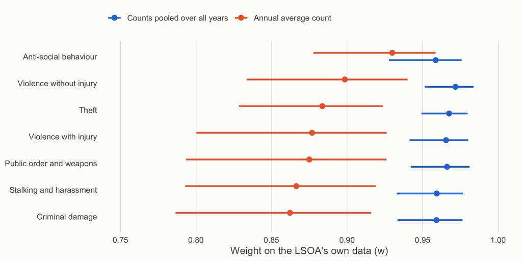

Figure 3: Estimated weight on each LSOA’s own data (w) for the crime indicators, under two readings of how the counts were shrunk. Points are medians, bars the middle 50% of LSOAs. w = 1 means shrinkage left the LSOA’s own data untouched. Approximate: residents-only denominators and local authority parent groups. Burglary (per property) is left out. Sources: IoD 2025 Files 7 and 8; my calculation.

With the annual average count, a typical LSOA has 8 (public order and weapons) to 16 (theft) incidents a year of each type. The weights are 0.86 to 0.93, and posterior errors are around 23% to 32% of the rate. With pooled counts the errors are roughly halved. Section 5 carries both through to the IMD.

### 3.6 Road casualties, rebuilt from DfT’s own records

The first version ran the shrinkage backwards for road casualties too, and found counts below 1 for many LSOAs (62% with weight below 0.5 under the annual reading). But this indicator is built from open data (technical report 4.9.26 to 4.9.30), so it can be rebuilt instead:

- 172,091 pedestrian and cyclist casualties in reported collisions in 2019 to 2023, of which 160,205 fall in England;
- weighted 3 if fatal, otherwise by DfT’s severity-adjusted probabilities (2 × serious + 1 × slight), for a mean weight of 1.29;
- shared equally between every LSOA within 100 m of the collision, which applies to 77% of them, because roads so often form LSOA boundaries;
- divided by residents plus 2023 BRES employment, standing in for the workplace population.

Table 9: Which version of the rebuilt road casualty rate matches the published indicator? ‘Zero LSOAs at zero’ is the share of LSOAs with no casualties whose value rounds to 0.000, as the published value does for almost all of them. Sources: DfT road safety open data 2019 to 2023; ONS LSOA boundaries; BRES 2023; IoD 2025 File 8; my calculation.

| Candidate | Rank correlation with published | Correlation | Zero LSOAs at zero |
| --- | --- | --- | --- |
| Unshrunk rate (residents + workplace) | 0.982 | 0.971 | 100% |
| Unshrunk rate (residents only) | 0.965 | 0.771 | 100% |
| Shrunk, counts pooled over 5 years | 0.948 | 0.960 | 0% |
| Shrunk, annual average count | 0.814 | 0.891 | 0% |

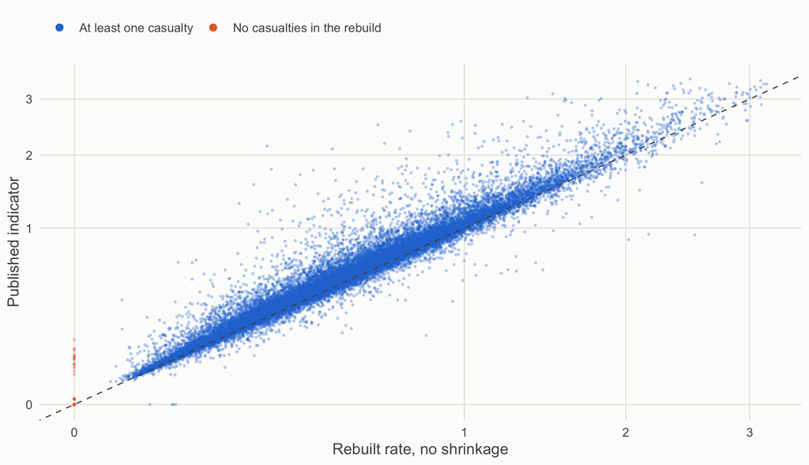

Figure 4: Road casualty rate per 1,000 at-risk people a year: rebuilt from DfT records without shrinkage (x) against the published IoD indicator (y), square-root scales. Orange points are LSOAs with no casualties in the rebuild. Sources: DfT road safety open data 2019 to 2023; ONS LSOA boundaries; BRES 2023; IoD 2025 File 8; my calculation.

- **The published indicator matches the unshrunk rate better than either shrunk version.** And 1,274 of the 1,278 LSOAs published at exactly 0 had no casualties in the rebuild. Shrinkage as Appendix C describes would pull every one of them up towards its parent group’s average; none of the shrunk versions leaves them at zero.
- **So, despite paragraph 4.9.30 saying shrinkage was applied, the published values behave as if it wasn’t** (my inference). That is a question for the research team. It matters for uncertainty: a typical LSOA has only 3 casualties behind its rate (4.0 once weighted), so the unshrunk rate carries a large chance error, about half the rate. Section 5 uses that error.
- **It also explains the Outdoors rebuild misses** in section 1, which all sit in these zero LSOAs.

### 3.7 Overcrowding and adult skills, from Census tables

Census 2021 tables TS053 (rooms) and TS052 (bedrooms) give the counts behind the two overcrowding components directly.

Table 10: Overcrowding rebuilt from Census 2021 counts, with shrinkage rebuilt using local authority parents. Sources: Census 2021 TS052 and TS053 (Nomis); IoD 2025 File 8; my calculation.

| Component | Median households | Median overcrowded | Correlation, raw vs published | Published = raw share (to 3 dp) | Correlation of pulls | Median w | Median SE (logit) |
| --- | --- | --- | --- | --- | --- | --- | --- |
| Bedrooms | 665 | 17 | 0.999 | 18% | 0.87 | 0.91 | 0.23 |
| Rooms | 665 | 27 | 0.999 | 15% | 0.87 | 0.93 | 0.19 |

- **Overcrowding was shrunk**, unlike road casualties: only about one LSOA in six publishes its raw share, and the rebuilt pull correlates 0.87 with the published one (again short of perfect, as the 2025 parent groups would explain).
- **The counts are small**, a median of 17 and 27 overcrowded households, so these are among the least certain indicators: a posterior error of about 23% of the rate.
- **Adult skills** comes from a special Census table that isn’t published, so only its denominator (people aged 25 to 66, from TS007A) can be rebuilt. Inverting the published rate gives a median count of 198, a weight of 0.97 and an error of about 8% of the rate.

### 3.8 What this means

- **Reverse engineering the error works.** On real data it gives back published counts to within rounding and errors to within a few percent.
- **It needs the denominator, and nothing in the published values supplies it.** Any assumed denominator gives a set of counts that shrinks exactly to the published rates. So the method turns “how uncertain is this rate?” into “what was the denominator, and how were the years combined?”. Mistakes can make the error too big or too small.
- **Where the source is open, rebuild it instead.** For road casualties that turned up something the published files couldn’t: the indicator doesn’t behave as if it was shrunk.
- **It can’t reach the standardised health ratios, the mental health composite or the pupil data.** Their counts, or the expected counts behind them, aren’t published.

## 4. Income and Employment error carried to the IMD

Each Monte Carlo draw:

1. Perturbs every LSOA’s Income and Employment rate by its posterior standard error from section 3.2, normal on the logit scale, centred on the published rate.
2. Reruns stages 5 to 7 exactly: rank both domains, transform them, add all seven domains with the published weights, rank the IMD, and recompute all five local authority measures.
3. Holds the other five domains at their published values.

The draws are centred on the published ranking. Tied published rates (3 decimal places) are spread across their rounding interval in published-rank order. With the noise set to zero, the simulation gives back every published Employment rank and local authority rank, every Income rank except the 3 that File 7 gives to two LSOAs at once, and every IMD rank except 2. There are 2,000 draws.

### 4.1 Two error models

The first version used one error model and called the result a lower bound. The review found two reasons it is lower than it needs to be, so there are now two models:

- **The Indices’ own model.** Independent binomial error in each domain, as Appendix C implies. This is the lower edge.
- **Correlated, design effect 2.**
  - Most people counted in the Employment domain are also in a benefit unit counted in the Income domain, so chance changes in the two counts move together. If every employment-deprived person were also in the Income count and people came and went independently, the correlation in each LSOA would be the square root of the ratio of the two counts. Its median is 0.62.
  - The Income count goes up and down a benefit unit at a time, not a person at a time, so it varies more than a binomial count. A design effect of 2 doubles the variances.
  - Both are assumptions that DWP Stat-Xplore data could later pin down.

Table 11: How the LSOA results depend on the error model: correlation between the Income and Employment errors, and the design effect (how many times the binomial variance the real variance is). Fewer draws than the main runs. Sources: IoD 2025 Files 6 to 9; my calculation.

| Correlation | Design effect | Median 90% range (ranks) | … most deprived 10% | Most deprived 10% under 95% likely to belong | Local authority average score, median range |
| --- | --- | --- | --- | --- | --- |
| None | 1.0 | 1,306 | 449 | 313 | 3 |
| None | 1.5 | 1,597 | 546 | 378 | 3 |
| None | 2.0 | 1,841 | 630 | 441 | 4 |
| Overlap model (median about 0.6) | 1.0 | 1,587 | 548 | 381 | 3 |
| Overlap model (median about 0.6) | 1.5 | 1,939 | 668 | 468 | 4 |
| Overlap model (median about 0.6) | 2.0 | 2,237 | 770 | 541 | 4 |
| 0.8 everywhere | 1.0 | 1,665 | 578 | 402 | 3 |
| 0.8 everywhere | 1.5 | 2,035 | 708 | 491 | 4 |
| 0.8 everywhere | 2.0 | 2,346 | 814 | 579 | 4 |

The correlation and the clustering compound. Either alone widens the median range by about a fifth to two fifths; together they take it from 1,306 to 2,346 ranks.

### 4.2 LSOAs

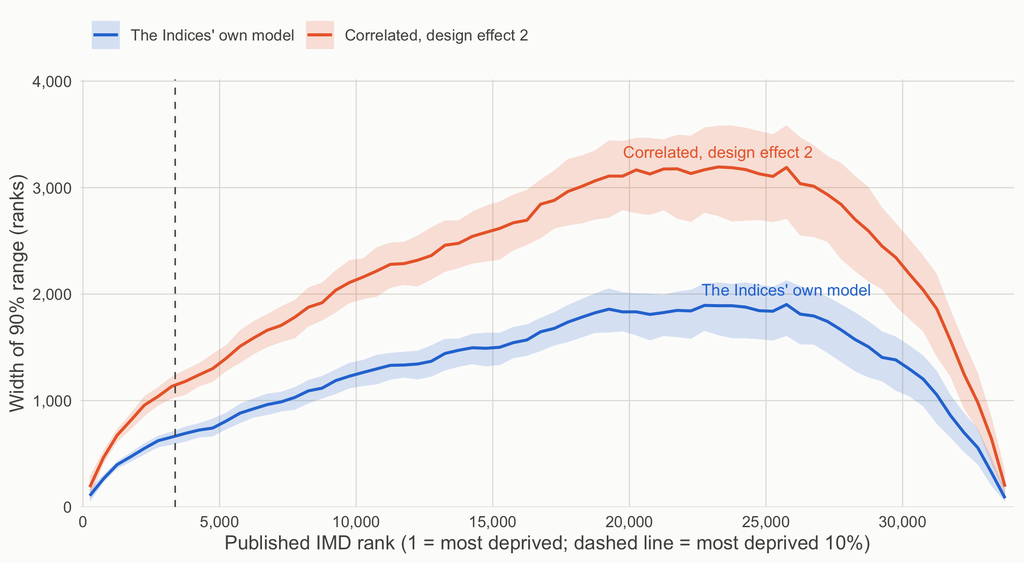

Figure 5: Width of the 90% range of each LSOA’s IMD rank across draws, by its published rank, in bands of 500 ranks, under the two error models. Lines are medians, bands the middle 50% of LSOAs. Ranges narrow at both ends because ranks can’t go below 1 or above 33,755. Only Income and Employment chance error is included. Sources: IoD 2025 Files 6 to 9; my calculation.

Table 12: LSOA rank ranges from Income and Employment chance error, under the two error models. Sources: IoD 2025 Files 6 to 9; my calculation.

| Measure | The Indices’ own model | Correlated, design effect 2 |
| --- | --- | --- |
| Median width of the 90% IMD rank range, all LSOAs | 1,306 ranks | 2,237 ranks |
| … for LSOAs in the most deprived 10% | 447 ranks | 768 ranks |
| … for LSOAs in the least deprived 10% | 712 ranks | 1,262 ranks |
| LSOAs whose 90% range covers two deciles | 37% | 61% |
| LSOAs whose 90% range covers three or more deciles | 0.0% | 0.8% |
| LSOAs between 5% and 95% likely to be in the most deprived 10% | 646 | 1,133 |
| LSOAs published in the most deprived 10% but less than 95% likely to belong there | 312 of 3,375 | 548 of 3,375 |
| Median width of the 90% Income domain rank range | 2,234 ranks | 3,165 ranks |
| Median width of the 90% Employment domain rank range | 4,565 ranks | 6,436 ranks |

- **A typical LSOA’s IMD rank could sit anywhere in a range of 1,306 to 2,237 places**, from these two domains alone.
- **The domain ranks themselves are less certain than the IMD rank.** The Employment domain rank has a median 90% range of 4,565 places even under the Indices’ own model, because Employment counts are smaller (median 115). The IMD averages over domains, which dampens each one’s error.
- **The most deprived end is the best separated**, as the exponential transform intends. Figure 6 shows how far apart two LSOAs need to be in the published ranking before the more deprived one stays ahead in most draws.

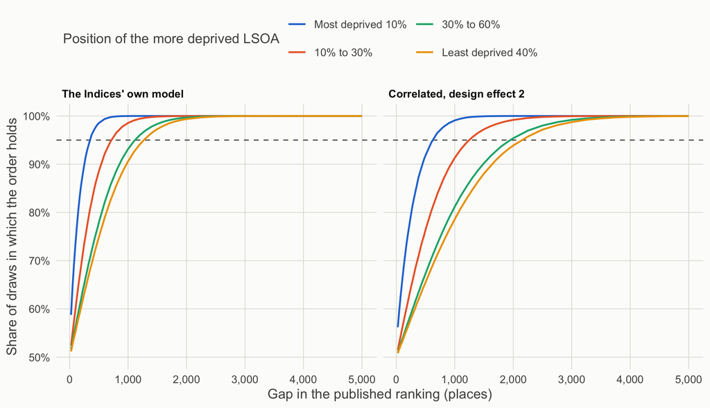

Figure 6: The share of draws in which an LSOA stays ahead of LSOAs published a given number of places below it, by where it sits in the ranking. Each point averages over 300 LSOAs spread through the ranking and, for each, the 21 LSOAs published closest to the gap. The dashed line is 95%. Only Income and Employment chance error is included. Sources: IoD 2025 Files 6 to 9; my calculation.

Table 13: Median gap in the published ranking needed for the more deprived LSOA to stay ahead in 95% of draws, at that gap and every larger gap tested. Sources: IoD 2025 Files 6 to 9; my calculation.

| Position in published ranking | The Indices’ own model | Correlated, design effect 2 |
| --- | --- | --- |
| Most deprived 10% | 350 | 700 |
| 10% to 30% | 700 | 1,300 |
| 30% to 60% | 1,200 | 2,000 |
| Least deprived 40% | 1,300 | 2,250 |

This replaces the first version’s “rank gap needed”, which tested a single partner LSOA at each gap and so jumped about. Averaging over neighbours smooths it. Under the Indices’ own model, LSOAs in the most deprived 10% need to be about 350 places apart; in the least deprived 40%, about 1,300. Under the correlated model, those gaps nearly double, to 700 and 2,250.

### 4.3 The children’s and older people’s indices

IDACI (children in income-deprived families) and IDAOPI (people aged 60 and over) are ranked on their own, and IDACI is used outside the Indices. Their counts are much smaller than the Income domain’s (medians of 85 and 60, against 310), so with the same error model as above:

Table 14: Rank ranges for the two supplementary indices, from chance error in their own counts (the Indices’ own model). Suppressed counts use the count recovered by running shrinkage backwards. Sources: IoD 2025 Files 6 to 8; my calculation.

| Index | Median count | Median 90% range (ranks) | … most deprived 10% | Range covers two or more deciles | Range covers three or more deciles | Most deprived 10% under 95% likely to belong |
| --- | --- | --- | --- | --- | --- | --- |
| IDACI | 85 | 4,066 | 1,187 | 85% | 29% | 928 |
| IDAOPI | 60 | 4,359 | 1,377 | 87% | 35% | 1,034 |

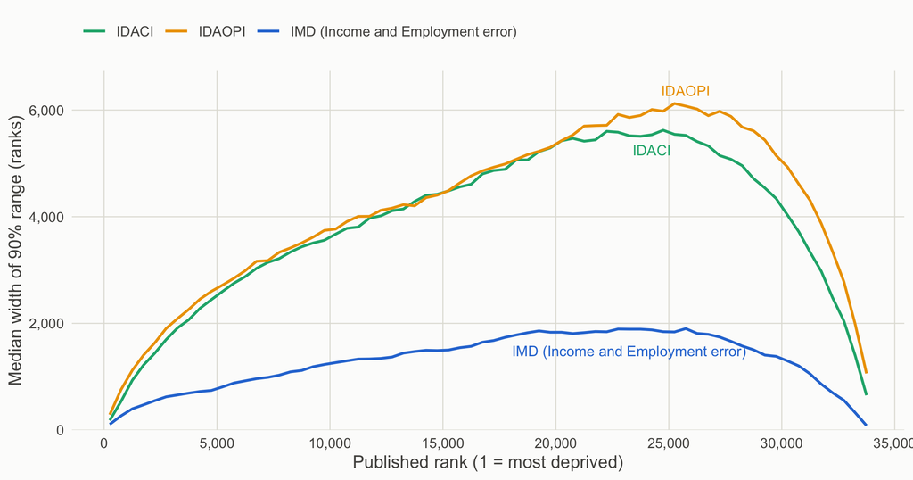

Figure 7: Width of the 90% rank range by published rank, in bands of 500 ranks: the IDACI and IDAOPI ranks, each from chance error in its own counts, and the IMD rank from Income and Employment chance error (both under the Indices’ own model). Sources: IoD 2025 Files 6 to 9; my calculation.

From chance error in their own counts alone, 85% of LSOAs have an IDACI range covering two or more deciles, and 928 of the LSOAs published in the most deprived 10% on IDACI are less than 95% likely to belong there. Any use of IDACI deciles or bands for individual LSOAs should allow for that.

### 4.4 Local authorities

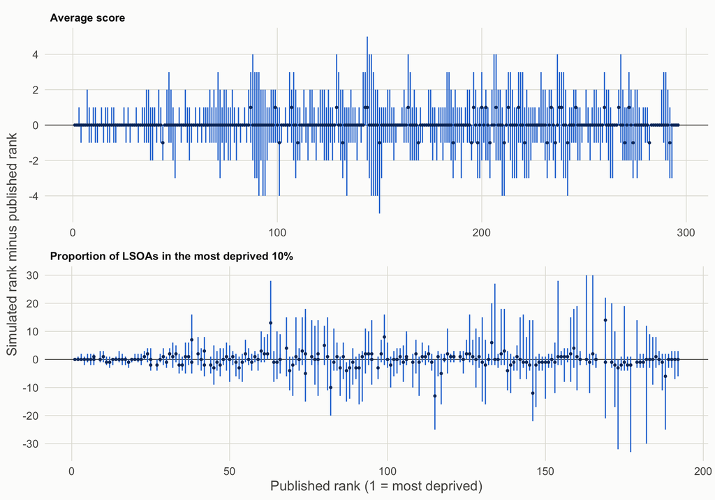

Figure 8: Local authority ranks on two IMD summary measures across draws, as differences from the published rank, under the Indices’ own model. Bars are 90% ranges, points medians. The lower panel leaves out the authorities with no LSOAs in the most deprived 10%, which tie at the bottom. Only Income and Employment chance error is included. Sources: IoD 2025 Files 6 to 10; my calculation.

Table 15: Local authority rank ranges from Income and Employment chance error, for all five summary measures and both error models. ‘Neighbours told apart’ is the share of authorities next to each other in the published ranking whose order holds in at least 95% of draws. Authorities with nothing in the most deprived 10% (or 30%, for extent) are left out of those measures, as they tie at the bottom. Sources: IoD 2025 Files 6 to 10; my calculation.

| Measure | Model | Authorities | Median width of 90% range (ranks) | Widest (ranks) | Neighbours told apart |
| --- | --- | --- | --- | --- | --- |
| Average score | The Indices’ own model | 296 | 2.5 | 8 | 27% |
| Average score | Correlated, design effect 2 | 296 | 4.0 | 11 | 12% |
| Average rank | The Indices’ own model | 296 | 3.0 | 8 | 23% |
| Average rank | Correlated, design effect 2 | 296 | 4.0 | 17 | 9% |
| Proportion of LSOAs in the most deprived 10% | The Indices’ own model | 192 | 9.0 | 42 | 19% |
| Proportion of LSOAs in the most deprived 10% | Correlated, design effect 2 | 192 | 15.0 | 45 | 10% |
| Extent | The Indices’ own model | 281 | 5.0 | 19 | 13% |
| Extent | Correlated, design effect 2 | 281 | 8.0 | 29 | 7% |
| Local concentration | The Indices’ own model | 296 | 5.0 | 13 | 7% |
| Local concentration | Correlated, design effect 2 | 296 | 8.0 | 24 | 3% |

- **Independent LSOA-level error largely cancels for local authorities.** On average score their 90% ranges are typically 2.5 to 4 ranks wide.
- **Neighbours still can’t usually be told apart.** Only 27% of neighbouring pairs on average score hold their order 95% of the time, even under the Indices’ own model.
- **The threshold and concentration measures are less stable.** Extent, local concentration and the proportion in the most deprived 10% all depend on a few LSOAs near a cut-off, and their ranges are two to four times wider than average score’s.

### 4.5 Do the ranges cover the truth?

Adding noise to published values and re-ranking gives a range around the published rank. That isn’t guaranteed to contain the true rank 90% of the time, especially where many areas are close together. A test with a known answer: take the published Income and Employment rates as the truth, make 20 “observed” datasets by adding error, run the simulation on each, and count how often the 90% ranges contain the true ranks.

Table 16: Coverage of the 90% ranges in a test with a known answer. ‘Top-10% claims correct’ is the share of LSOAs a run calls at least 95% likely to be in the most deprived 10% that truly are. Sources: IoD 2025 Files 6 to 9; simulated data; my calculation.

| How the error was made, and how it was analysed | LSOA coverage | Lowest decile | Top-10% claims correct | Local authority coverage (average score) |
| --- | --- | --- | --- | --- |
| Correlated, design effect 2, analysed with own model | 65.8% | 65.5% | 99.0% | 85.0% |
| Correlated, design effect 2, analysed with the same | 89.4% | 88.9% | 99.7% | 95.4% |
| Own model, analysed with own model | 89.5% | 88.7% | 99.9% | 96.6% |

- **With the right error model, the ranges work.** LSOA coverage is 89.5%, close to 90% in every decile. Local authority coverage on average score is 96.6%, so those ranges are a little conservative.
- **With too optimistic an error model, they don’t.** If the real error is the correlated, design-effect-2 kind but the analysis assumes the Indices’ own model, LSOA coverage falls to 65.8%. So the ranges are only as good as the error model, and section 4.1’s upper edge isn’t a pessimistic extreme: it’s what the ranges need if that model is the right one.
- **“Most deprived 10%” claims at 95% hold up** in every case: 99.0% or more of the LSOAs called at least 95% likely to be in the most deprived 10% truly are.

## 5. Error in the other domains

Section 4 holds five domains fixed. Here every domain carries error, using the stage 4 builders from section 1. Each draw perturbs the indicators, rebuilds the domain and sub-domain scores, and adds the change to the published scores before ranking. With the noise set to zero this gives back every published domain rank except 11, all of them where File 7 gives two LSOAs the same domain or sub-domain rank. There are 1,000 draws per layer. The layers build on each other:

1. **Income and Employment**, the Indices’ own model (as section 4).
2. **Plus the chance error that open data can size:** the eight crime indicators (section 3.5, annual-average reading; burglary with Census households standing in for properties), overcrowding and adult skills (section 3.7) and road casualties (section 3.6, unshrunk). Layer 2b is the same with the pooled crime reading.
3. **Plus assumed errors for everything else** (Table 17), including errors shared by every LSOA in a local authority. These are order-of-magnitude guesses meant to show what kinds of error matter. They are not estimates.

Table 17: The assumed errors in layer 3. ‘Shared’ is the share of the error variance common to every LSOA in a local authority. Scales: ‘log’ is a relative error, ‘logit’ is on the log-odds scale, ‘add’ is in the indicator’s own units.

| Item | Scale | Size | Shared | Basis |
| --- | --- | --- | --- | --- |
| Comparative illness and disability ratio | log | From assumed counts | 0% | Poisson error for about 150 claimants in an average LSOA (rough national total), scaled by the ratio |
| Years of potential life lost | log | From assumed counts | 0% | About 20 deaths under 75 in five years in an average LSOA, inflated 1.5 times for the age weighting |
| Acute morbidity | log | From assumed counts | 0% | About 200 emergency admissions in two years in an average LSOA, inflated 1.5 times for repeat admissions |
| Mental health indicator | add | 0.15 | 0% | One fifth of the spread of the published composite score |
| Children and young people sub-domain | add | 0.2 | 0% | About a quarter of the spread of the published sub-domain score (pupil data not public) |
| Connectivity score | add | 2 | 50% | Model error of 2 points on a 0 to 100 score |
| Housing affordability components | logit | 0.2 | 50% | Model error; half shared, as the model works at housing market area level |
| Homelessness (both indicators) | log | 0.15 | 100% | Supplied at local authority level, so the whole error is shared |
| Broadband speed | add | 0.1 | 0% | Small measurement error in the published score |
| Patient-to-GP ratio | log | 0.05 | 0% | Error in sharing practice figures out to LSOAs |
| Housing in poor condition | logit | 0.3 | 50% | Model error (national survey scaled down to dwellings); half shared |
| Housing energy performance | add | 1 | 0% | Imputation for the 40% of homes without a valid EPC |
| Housing lacking private outdoor space | add | 2 | 0% | Imputation of implausible values |
| Air quality | log | 0.1 | 50% | Model error on a 1 km grid; half shared |
| Noise | logit | 0.3 | 50% | Model error; half shared |
| Population denominators | log | 0.03 | 50% | About 2% error in local authority totals (ONS publishes intervals of this order) and 2% within; applied to Income and Employment rates |

Table 18: LSOA IMD rank ranges as error is added to more domains. Sources: IoD 2025 Files 6 to 9; DfT road safety data; Census 2021; my calculation; layer 3 rests on the assumptions above.

| Layer | Median 90% range (ranks) | … most deprived 10% | … least deprived 10% | Covers two or more deciles | Covers three or more deciles | Most deprived 10% under 95% likely to belong |
| --- | --- | --- | --- | --- | --- | --- |
| 1. Income and Employment | 1,306 | 448 | 711 | 37% | 0.0% | 312 |
| 2. Plus open-data chance error (crime: annual average reading) | 1,609 | 526 | 979 | 45% | 0.0% | 373 |
| 2b. As 2, crime: pooled reading | 1,472 | 497 | 875 | 41% | 0.0% | 343 |
| 3. Plus assumed errors for everything else | 2,885 | 1,009 | 1,668 | 74% | 3.2% | 707 |

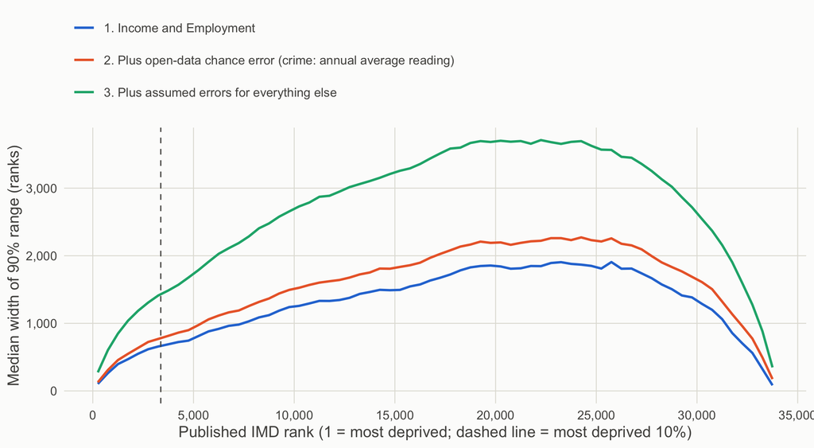

Figure 9: Median width of the 90% IMD rank range by published rank, in bands of 500, as error is added to more domains. Layer 3 rests on assumed errors. Sources: IoD 2025 Files 6 to 9; DfT road safety data; Census 2021; my calculation.

Table 19: Median width of the 90% range of each domain’s own rank, by layer. Zero means the domain is held fixed in that layer. Sources: as above.

| Layer | Income | Employment | Education, skills and training | Health and disability | Crime | Barriers to housing and services | Living environment |
| --- | --- | --- | --- | --- | --- | --- | --- |
| 1. Income and Employment | 2,235 | 4,566 | 0 | 0 | 0 | 0 | 0 |
| 2. Plus open-data chance error (crime: annual average reading) | 2,233 | 4,561 | 2,349 | 0 | 6,288 | 1,238 | 2,109 |
| 2b. As 2, crime: pooled reading | 2,232 | 4,564 | 2,349 | 0 | 2,911 | 1,239 | 2,106 |
| 3. Plus assumed errors for everything else | 2,631 | 4,838 | 4,784 | 8,795 | 6,291 | 5,929 | 8,325 |

Table 20: Local authority rank ranges on average score and extent, by layer. Sources: as above.

| Layer | Measure | Median width of 90% range (ranks) | Widest (ranks) | Neighbours told apart |
| --- | --- | --- | --- | --- |
| 1. Income and Employment | Average score | 3 | 8 | 27% |
| 2. Plus open-data chance error (crime: annual average reading) | Average score | 3 | 8 | 21% |
| 2b. As 2, crime: pooled reading | Average score | 3 | 8 | 23% |
| 3. Plus assumed errors for everything else | Average score | 16 | 28 | 1% |
| 1. Income and Employment | Extent | 5 | 19 | 13% |
| 2. Plus open-data chance error (crime: annual average reading) | Extent | 6 | 21 | 10% |
| 2b. As 2, crime: pooled reading | Extent | 5 | 21 | 11% |
| 3. Plus assumed errors for everything else | Extent | 14 | 41 | 0% |

What the layers show:

- **Open-data chance error in the other domains widens LSOA ranges by about a quarter.** The median goes from 1,306 to 1,609 ranks (1,472 with the pooled crime reading). Crime is the biggest contributor: its own domain rank has a median range of 6,288 places under the annual reading.
- **The assumed errors matter more than the measured ones.** With them, the median range reaches 2,885 ranks, and 3.2% of LSOAs have ranges covering three or more deciles. The health domain alone gets a median range of 8,795 places from assumed errors. So the biggest gap in what can be said about IMD uncertainty is the error in the inputs that nobody outside can measure.
- **Shared errors are what move local authorities.** Layer 2 adds only independent LSOA-level error, and local authority ranges barely change. Layer 3 adds errors shared across each authority (homelessness, modelled inputs, population denominators), and the median range on average score goes from 3 to 16 ranks.

## 6. Formal confidence sets for local authorities

The ranges above are percentile ranges of each authority’s simulated rank. The `csranks` package (Mogstad, Romano, Shaikh and Wilhelm 2024) gives confidence sets with stated coverage, from the estimates and their covariance, here taken from the simulated average scores:

- **marginal:** each authority’s set covers its true rank 90% of the time;
- **simultaneous:** all 296 sets cover all the true ranks at once 90% of the time, which is what a claim about the whole league table needs;
- **“among the 10 most deprived”:** the authorities that, with 90% confidence, could be among the 10 most deprived on average score.

Table 21: Confidence sets for local authority ranks on average IMD score, 90% level. Sources: IoD 2025 Files 6 to 10; simulated covariances from sections 4 and 5; csranks; my calculation.

| Error included | Simulation range | Marginal set | Simultaneous set | Widest simultaneous set | Could be the most deprived | Could be among the 10 most deprived |
| --- | --- | --- | --- | --- | --- | --- |
| All layers, with assumed and shared errors (15, layer 3) | 16.0 | 43 | 60 | 79 | 2 | 21 |
| Income and Employment, Indices’ own model (07) | 2.5 | 5 | 7 | 19 | 1 | 12 |
| Income and Employment, correlated, design effect 2 (07) | 4.0 | 10 | 14 | 28 | 1 | 13 |

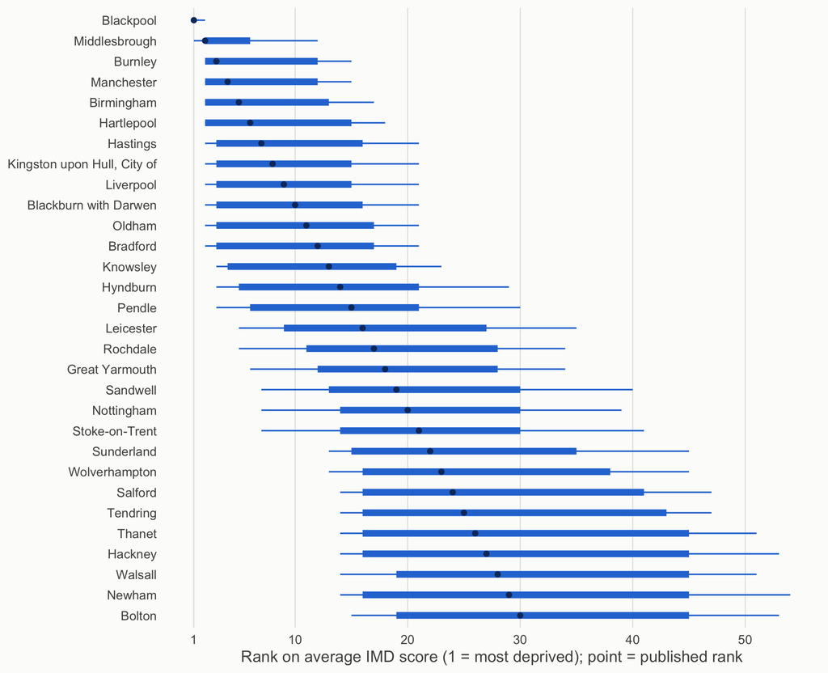

Figure 10: The 30 most deprived local authorities on published average IMD score, with their 90% marginal (thick) and simultaneous (thin) confidence sets for rank, using the covariance from all layers including assumed and shared errors (section 5, layer 3). Sources: IoD 2025 Files 6 to 10; csranks; my calculation; rests on the assumptions in section 5.

- **Formal sets are wider than the simulation ranges**, roughly two to three times for marginal sets, because they account for the uncertainty in every comparison an authority’s rank depends on.
- **Only the most deprived authority’s rank is pinned down.** Blackpool has a simultaneous set of 1 to 2 even with all layers; 2 authorities could be the most deprived. Further down, simultaneous sets span tens of places.
- **From Income and Employment error alone, 12 authorities could be among the 10 most deprived.** With all layers, 21 could. Statements like “the 10 most deprived local authorities” are fairly robust to chance error in these two domains, less so once other errors are allowed for.

## 7. Caveats and next steps

**Caveats.**

- **Parent groups.** Everything uses the local authority as the shrinkage parent, not the 2025 supergroup-within-local-authority. For Income and Employment this barely matters (w ≈ 1). For the rare-event indicators it makes the groups too coarse, which overstates the error (section 3.4).
- **The error models are assumptions.** The Indices’ own model is binomial and independent; the upper model’s correlation and design effect are reasoned, not measured. Section 4.5 shows the ranges are only as good as the model. Layer 3’s errors are guesses.
- **Systematic error is mostly absent.** Layer 3 includes some shared errors as stand-ins, but benefit take-up, police recording practice and the time-point mismatches are not modelled.
- **Method choices are held fixed**: the domain weights, the factor-analysis weights, the exponential constant and the 70/30 split. Varying them is a separate layer still to do.
- **The road casualty and crime denominators are approximate**: BRES employment stands in for the workplace population, and residents for the crime at-risk population.

**Next steps.**

- **Get the shrinkage parent groups right.** Download the GeoDS classification (needs registration) and rerun sections 3 and 4 with supergroup-within-local-authority parents. Section 3.3 shows what to look for: the Income pull should then fit as well as in 2019.
- **Measure the error model with DWP Stat-Xplore** (needs an API key): month-to-month variation in benefit counts against the binomial, and the overlap between the Income and Employment counts. That would replace the assumed correlation and design effect with measured ones.
- **Replace layer 3’s guesses where possible**: expected counts for the health ratios from national age-sex rates; ONS population estimate intervals for the denominators; police.uk counts to check crime’s year-to-year variation.
- **Add the method layer**, as above, and keep it separate from data error.
- **Ask MHCLG and the research team** about the points in llm_output/imd_uncertainty_questions_for_iod_team.md: the posterior standard errors, the at-risk denominators, pooled or annual counts, whether road casualties were shrunk, how the 2019 Employment domain was shrunk, and the normal-score and wider-barriers details.

## Sources, code and outputs

- [English Indices of Deprivation 2025 (MHCLG, 30 October 2025, files updated 17 November 2025)](https://www.gov.uk/government/statistics/english-indices-of-deprivation-2025): technical report, research report, and data Files 6 to 10.
- [English Indices of Deprivation 2019 (MHCLG)](https://www.gov.uk/government/statistics/english-indices-of-deprivation-2019): Files 6 to 8.
- [DfT road safety open data](https://www.gov.uk/government/statistical-data-sets/road-safety-open-data): collisions and casualties, 2019 to 2023.
- [ONS Open Geography Portal](https://geoportal.statistics.gov.uk/): LSOA (December 2021) boundaries, generalised and clipped.
- [Census 2021 bulk downloads (Nomis)](https://www.nomisweb.co.uk/sources/census_2021_bulk): TS052, TS053 and TS007A.
- [Business Register and Employment Survey (Nomis)](https://www.nomisweb.co.uk/datasets/newbres6pub): open-access employment by LSOA, 2023.
- [UK LSOA classification (2021/2 LSOAC), Geographic Data Service](https://data.geods.ac.uk/dataset/lsoac): the 2025 shrinkage parent groups (not used here; needs registration).
- Mogstad, Romano, Shaikh and Wilhelm (2024), [Inference for ranks](https://econpapers.repec.org/RePEc:oup:restud:v:91:y:2024:i:1:p:476-518.), *Review of Economic Studies*; R package csranks.
- Research note with all 55 indicators, weights and sources: llm_output/imd_rank_uncertainty_research.md. Review of the first version and the plan this version follows: llm_output/imd_uncertainty_review_and_plan.md.
- R scripts: code/imd_uncertainty, with a README listing each script. `00_run_all.R` rebuilds everything and renders this report.
- Output files in docs/chunks/imd_uncertainty/outputs:
  - `lsoa_imd_rank_ranges_income_employment.csv`: every LSOA’s IMD rank range and decile probabilities from section 4, under both error models;
  - `lsoa_idaci_idaopi_rank_ranges.csv`: IDACI and IDAOPI rank ranges;
  - `lsoa_imd_rank_ranges_by_layer.csv` and `lad_rank_ranges_by_layer.csv`: the section 5 layers.